# Data visualisation

Tushar Bajaj

# 1 Data

Let us look at NSSO-68 data for West Bengal. We can see that it consists of various categorical and continuous variables.

- A categorical variable is a variable that can take on one of a limited, and usually fixed, number of possible values.Categorical data may derive from observations made of qualitative data that are summarised as counts or cross tabulations, or from observations of quantitative data grouped within given intervals.These are gender,**religion**.
- Discrete variables are numeric variables that have a countable number of values between any two values. A discrete variable is always numeric. These are household size, **age**.
- Continuous variables are numeric variables that have an infinite number of values between any two values.These can be **land ownership**, time series/

## 1.1 Level 2 data

Let us look at variables of level 2 database. It is collected at the level of household characteristics

| fsu serial no. | region | subregion | districtname | sector | sample hhld. no. | hhsize | cathhsize | occupation | hhtype | religion | social group | landowned | catlandown | landposs | landcult | ismgnrega | numofmgnrega | isbankpostofficeaccnt | weight |
| --- | --- | --- | --- | --- | --- | --- | --- | --- | --- | --- | --- | --- | --- | --- | --- | --- | --- | --- | --- |
| 44369 | CentralPlains | Barddhaman | Barddhaman | urban | 01 | 6 | small | Directors and Chief Executives | uselfemployed | Hinduism | OBC | 0.001 | marginal | 0.001 |  |  |  |  | 564 |
| 44002 | SouthernPlains | Kolkata | South Twenty Four Parganas | urban | 02 | 1 | single |  | uother | Hinduism | Others | 0.042 | marginal | 0.042 |  |  |  |  | 5134.5 |
| 72417 | EasternPlains | Chinsura | Nadia | rural | 02 | 2 | single | Precision Workers in Metal and Related Materials | rcaslabnonagr | Hinduism | OBC | 0.013 | marginal | 0.013 |  | no |  |  | 59170.96 |
| 72433 | EasternPlains | Chinsura | Nadia | rural | 01 | 2 | single | Agricultural, Fishery and Related Labourers | rcaslabagr | Hinduism | Others | 0.247 | marginal | 0.247 | 0.234 | yes | 1 | yes | 21068.46 |
| 72105 | SouthernPlains | Kolkata | South Twenty Four Parganas | rural | 01 | 4 | small | Market Gardners &amp; Crop Growers | selfempagri | Islam | Others | 1.608 | v.small |  | 1.605 | no |  |  | 51910.07 |
| 72438 | EasternPlains | Chinsura | Nadia | rural | 01 | 1 | single |  | rothers | Islam | Others | 0.008 | marginal | 0.008 |  | no |  |  | 16459.44 |
| 72243 | SouthernPlains | Kolkata | South Twenty Four Parganas | rural | 01 | 5 | small | Glass, Ceramics and Related Plant Operators | rcaslabnonagr | Islam | Others | 0.133 | marginal | 0.133 | 0.099 | no |  |  | 18530.21 |
| 44077 | CentralPlains | Chinsura | Hugli | urban | 03 | 2 | single |  | uother | Hinduism | Others | 0.014 | marginal | 0.014 |  |  |  |  | 21879 |
| 44806 | SouthernPlains | Kolkata | Kolkata | urban | 04 | 6 | small | Directors and Chief Executives | uselfemployed | Hinduism | Others | 0.006 | marginal |  |  |  |  |  | 20735 |
| 72701 | CentralPlains | Chinsura | Hugli | rural | 01 | 1 | single |  | rothers | Hinduism | OBC | 0.004 | marginal | 0.004 |  | no |  |  | 34485.93 |

[output cut: 490 more lines]

## 1.2 Level 3 data

Level 3 data has been collected at level of Individual.

| fsu serial no. | region | subregion | districtname | sector | sample hhld. no. | person serial no. | relationtohead | education | sex | age | marital status | weight3 |
| --- | --- | --- | --- | --- | --- | --- | --- | --- | --- | --- | --- | --- |
| 44311 | CentralPlains | Chinsura | Hugli | urban | 01 | 01 | self | middle | male | 56 | married | 9724 |
| 72170 | CentralPlains | Barddhaman | Barddhaman | rural | 02 | 05 | grandchild | secondary | female | 16 | nevermarried | 4251.44 |
| 72214 | SouthernPlains | Kolkata | South Twenty Four Parganas | rural | 01 | 01 | self | primary | male | 63 | married | 389.33 |
| 44051 | SouthernPlains | Kolkata | North Twenty Four Parganas | urban | 01 | 02 | sibbling/inlaw | secondary | female | 65 | nevermarried | 1788 |
| 72648 | EasternPlains | Barhampur | Murshidabad | rural | 01 | 04 | spouse of married child | middle | female | 26 | married | 3518.15 |
| 72119 | EasternPlains | Chinsura | Nadia | rural | 01 | 01 | self | notliterate | male | 50 | married | 5577.21 |
| 41991 | EasternPlains | Barhampur | Murshidabad | urban | 01 | 06 | grandchild | belowprimary | female | 4 | nevermarried | 2365 |
| 72690 | EasternPlains | Maldah | Uttar Dinajpur | rural | 01 | 04 | unmarried child | belowprimary | male | 11 | nevermarried | 9663.01 |
| 72170 | CentralPlains | Barddhaman | Barddhaman | rural | 02 | 03 | married child | postgraduate | male | 44 | married | 4251.44 |
| 72278 | SouthernPlains | Kolkata | North Twenty Four Parganas | rural | 01 | 01 | self | notliterate | male | 60 | married | 13494.34 |

[output cut: 490 more lines]

# 2 Category variables

## 2.1 Regions

```r
wb2%>% select(region,subregion,districtname)%>%group_by(region,subregion,districtname)%>%arrange_all()%>%unique()
```

| region | subregion | districtname |
| --- | --- | --- |
| CentralPlains | Barddhaman | Barddhaman |
| CentralPlains | Chinsura | Hugli |
| CentralPlains | Howrah | Haora |
| EasternPlains | Barhampur | Birbhum |
| EasternPlains | Barhampur | Murshidabad |
| EasternPlains | Chinsura | Nadia |
| EasternPlains | Howrah | Murshidabad |
| EasternPlains | Maldah | Dakshin Dinajpur * |
| EasternPlains | Maldah | Maldah |
| EasternPlains | Maldah | Uttar Dinajpur |

[output cut: 15 more lines]

## 2.2 Sector

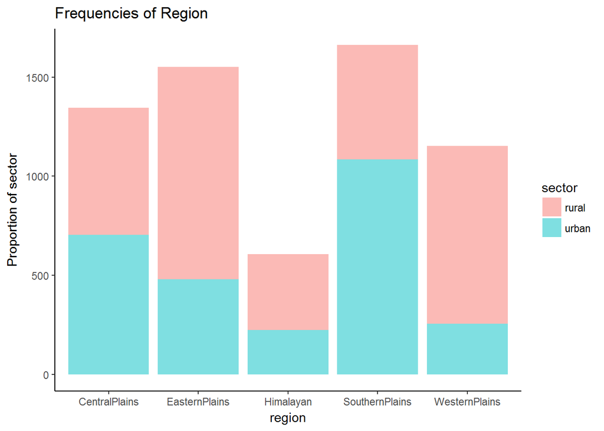

```r
wb2%>%ggplot() + geom_bar(mapping=aes(x=region,fill=sector),alpha=0.5) +ggtitle("Frequencies of Region") +ylab("Proportion of sector") + theme_classic()
```

Sourthern and Central plains are highly urbanised. These is region of KOlkata and Howrah .

## 2.3 Religion

**Hypothesis-1**: Muslims have larger households than others

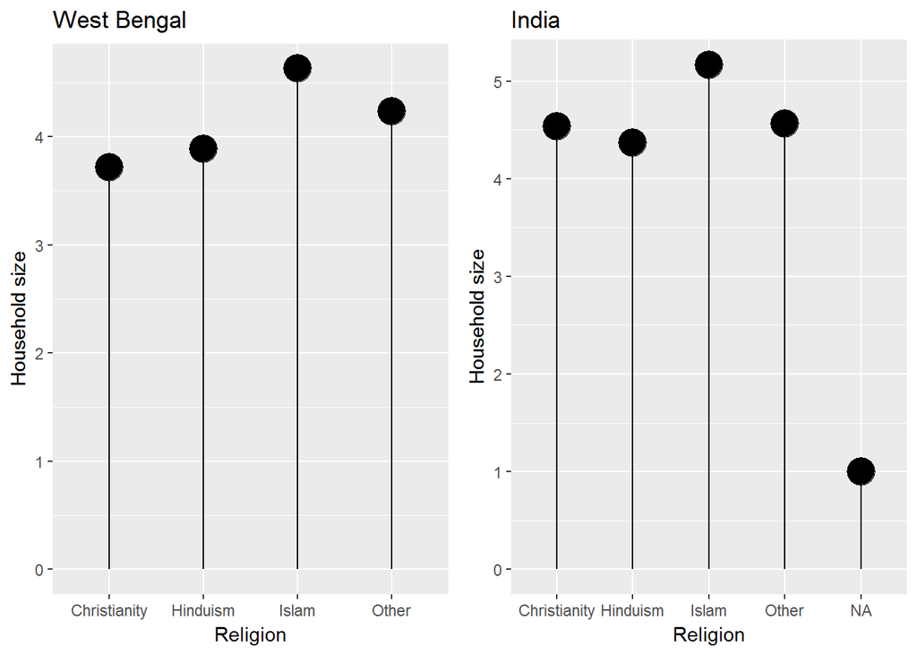

```r
wbrel=wb2%>%select(religion,hhsize)%>%mutate(religion=fct_lump(religion,3))%>%group_by(religion)%>%mutate(meanhh=mean(hhsize))%>%unique()
wbrelgg=ggplot(wbrel,aes(x=religion,y=meanhh)) +  geom_point(size=7)+geom_segment(aes(x=religion,xend=religion,y=0,yend=meanhh)) +
      labs(title="West Bengal",y="Household size",x="Religion")

airel=ai.2%>%select(Religion,hhsize)%>%mutate(Religion=fct_lump(Religion,3))%>%group_by(Religion)%>%mutate(meanhh=mean(hhsize))%>%unique()
airelgg=ggplot(airel,aes(x=Religion,y=meanhh)) +  geom_point(size=7)+geom_segment(aes(x=Religion,xend=Religion,y=0,yend=meanhh)) +
      labs(title="India",y="Household size",x="Religion")

grid.arrange(wbrelgg,airelgg,nrow=1,ncol=2)
```

### 2.3.1 Sub-Regional

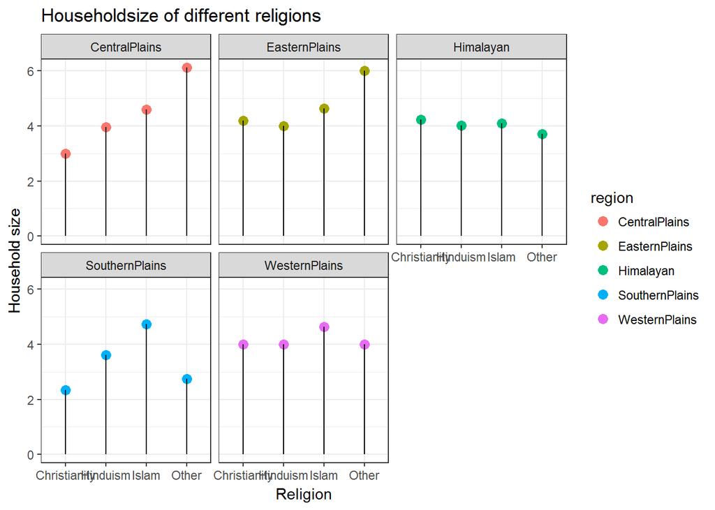

```r
x=wb2%>%select(region,religion,hhsize)%>%mutate(religion=fct_lump(religion,3))%>%group_by(region,religion)%>%mutate(meanhh=mean(hhsize))%>%unique()
ggplot(x,aes(x=religion,y=meanhh)) +  geom_point(size=3,aes(col=region))+geom_segment(aes(x=religion,xend=religion,y=0,yend=meanhh))  +
      labs(title="Householdsize of different religions",y="Household size",x="Religion")+ theme_bw()+facet_wrap(~region)
```

The reason for this can be explained by Income level, Fertility level and Education level of woman in religious groups.Moreover,sample size is less for other religious levels.

# 3 Continuous variables

## 3.1 Landownership

Land ownership with respect to Social group and Religion

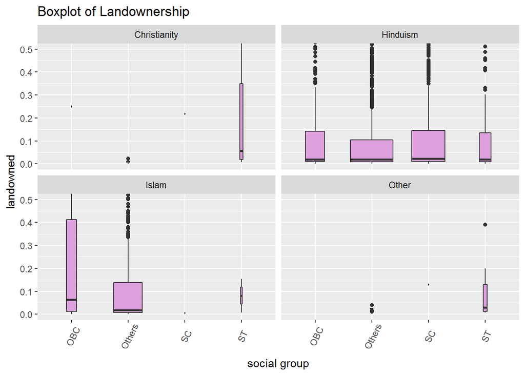

```r
wb2$religion=fct_lump(wb2$religion,3)
ggplot(wb2,aes(x=`social group`,y=landowned)) +
  geom_boxplot(varwidth = TRUE,fill="plum")+
  coord_cartesian(ylim=c(0,0.5))+
  theme(axis.text.x = element_text(angle=65, vjust=0.6))+labs(title="Boxplot of Landownership") +facet_wrap(~religion)
```

## 3.2 Correlation

Pearson correlation between land owned, land possessed , land cultivated and household size.

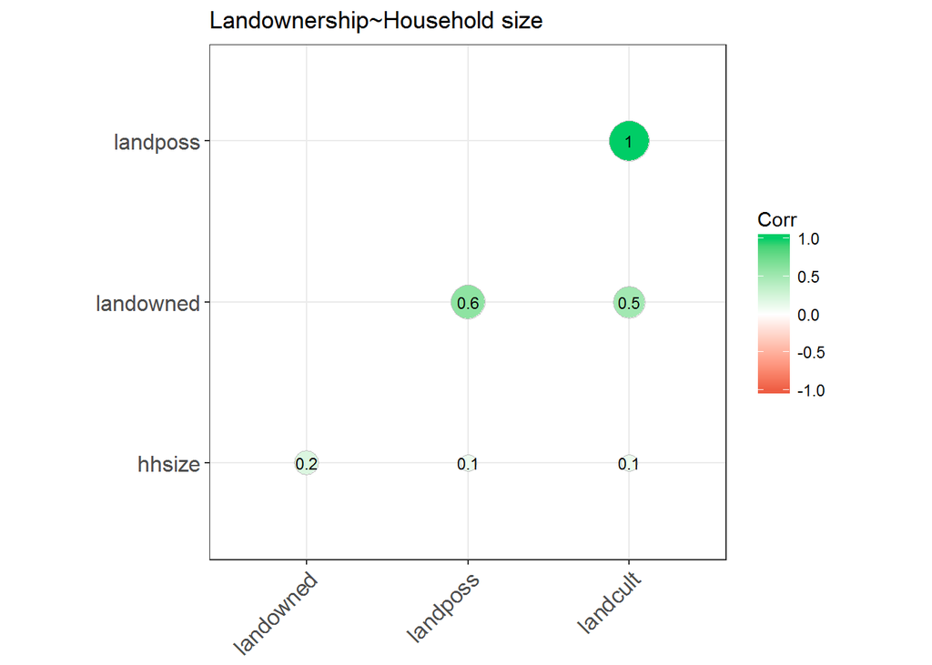

```r
library(ggcorrplot)
corr=wb2%>%select(hhsize,landowned,landposs,landcult)%>%na.omit()%>%
  cor()%>%round(1)
ggcorrplot(corr, hc.order = TRUE,
           type = "lower",
           lab = TRUE,
           lab_size = 3,
           method="circle",
           colors = c("tomato2", "white", "springgreen3"),
           title="Landownership~Household size",
           ggtheme=theme_bw)
```

# 4 Education

*Hypothesis*: Discrimination against girl in education

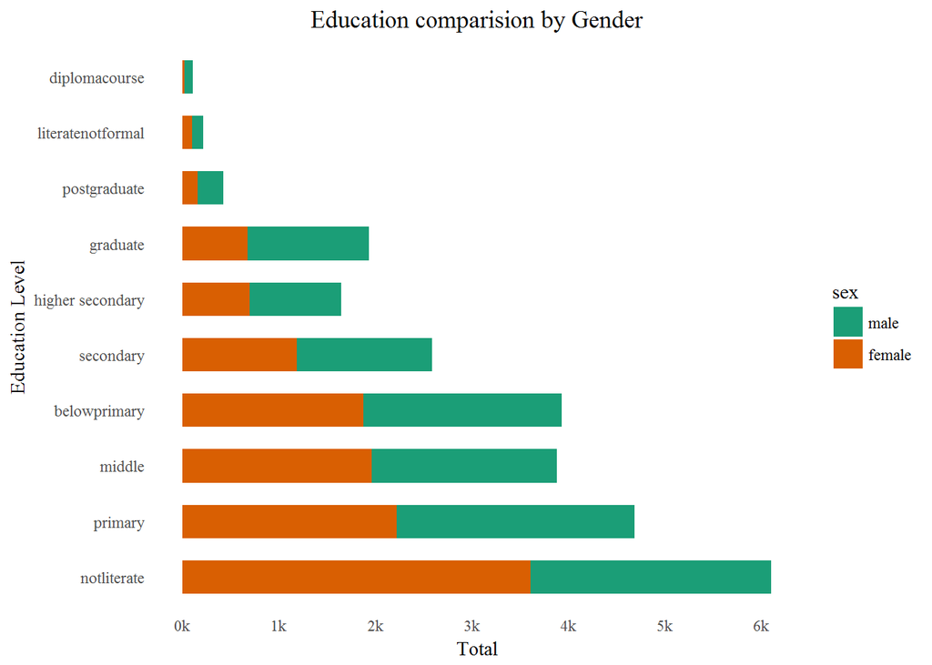

```r
library(ggthemes)
educount=wb3%>%select(education,sex)%>%na.omit()%>%group_by(education,sex)%>%count()
brks =seq(-8000, 8000, 1000)
lbls = paste0(as.character(c(seq(8, 0, -1), seq(1, 8, 1))), "k")

   ggplot(educount, aes(x = fct_reorder2(education,sex,n),y=n, fill = sex)) +   # Fill column
     geom_bar(stat="identity",width = .6) +   # draw the bars
     scale_y_continuous(breaks = brks,labels = lbls) +
     coord_flip() +  # Flip axes
  labs(title="Education comparision by Gender",y="Total",x="Education Level") +
  theme_tufte() +  # Tufte theme from ggfortify
  theme(plot.title = element_text(hjust = .5),
        axis.ticks = element_blank()) +   # Centre plot title
  scale_fill_brewer(palette = "Dark2")
```

Hence There is a clear discrimination against girl child in West Bengal too.

# 5 Way Ahead

- Biggest Take away from this excercise is that core of the data analysis is data wrangling. For each stage, one needs to understand the data and latent meanings behind it. For this, domain expertise comes handy.
- Next steps is to learn modelling the data and GIS .